# tidyverse dates_times_timezones

# Working with Dates, Times and Timezones

R has special object classes for dates and date-times. It is often worthwhile to convert a column in a dataframe to one of these special object types, because you can do some very useful things with date or date-time objects, including pull out the month or day of the week from the observations in the object, or determine the time difference between two values. Many of the examples here use the ext_tracks:

```r
library(tidyr)
library(dplyr)
library(readr)
ext_tracks_file <- "data/Rprogenv/ebtrk_atlc_1988_2015.txt"
# Create a vector of the width of each column
ext_tracks_widths <- c(7, 10, 2, 2, 3, 5, 5, 6, 4, 5, 4, 4, 5, 3, 4, 3, 3, 3,
                       4, 3, 3, 3, 4, 3, 3, 3, 2, 6, 1)
# Create a vector of column names, based on the online documentation for this data
ext_tracks_colnames <- c("storm_id", "storm_name", "month", "day",
                         "hour", "year", "latitude", "longitude",
                         "max_wind", "min_pressure", "rad_max_wind",
                         "eye_diameter", "pressure_1", "pressure_2",
                         paste("radius_34", c("ne", "se", "sw", "nw"), sep = "_"),
                         paste("radius_50", c("ne", "se", "sw", "nw"), sep = "_"),
                         paste("radius_64", c("ne", "se", "sw", "nw"), sep = "_"),
                         "storm_type", "distance_to_land", "final")
# Read the file in
ext_tracks <- read_fwf(ext_tracks_file, fwf_widths(ext_tracks_widths, ext_tracks_colnames),na="-99")
head(ext_tracks)
```

| storm_id | storm_name | month | day | hour | year | latitude | longitude | max_wind | min_pressure | rad_max_wind | eye_diameter | pressure_1 | pressure_2 | radius_34_ne | radius_34_se | radius_34_sw | radius_34_nw | radius_50_ne | radius_50_se | radius_50_sw | radius_50_nw | radius_64_ne | radius_64_se | radius_64_sw | radius_64_nw | storm_type | distance_to_land | final |
| --- | --- | --- | --- | --- | --- | --- | --- | --- | --- | --- | --- | --- | --- | --- | --- | --- | --- | --- | --- | --- | --- | --- | --- | --- | --- | --- | --- | --- |
| AL0188 | ALBERTO | 08 | 05 | 18 | 1988 | 32.0 | 77.5 | 20 | 1015 | NA | NA | NA | NA | 0 | 0 | 0 | 0 | 0 | 0 | 0 | 0 | 0 | 0 | 0 | 0 | * | 218 | . |
| AL0188 | ALBERTO | 08 | 06 | 00 | 1988 | 32.8 | 76.2 | 20 | 1014 | NA | NA | NA | NA | 0 | 0 | 0 | 0 | 0 | 0 | 0 | 0 | 0 | 0 | 0 | 0 | * | 213 | . |
| AL0188 | ALBERTO | 08 | 06 | 06 | 1988 | 34.0 | 75.2 | 20 | 1013 | NA | NA | NA | NA | 0 | 0 | 0 | 0 | 0 | 0 | 0 | 0 | 0 | 0 | 0 | 0 | * | 149 | . |
| AL0188 | ALBERTO | 08 | 06 | 12 | 1988 | 35.2 | 74.6 | 25 | 1012 | NA | NA | NA | NA | 0 | 0 | 0 | 0 | 0 | 0 | 0 | 0 | 0 | 0 | 0 | 0 | * | 126 | . |
| AL0188 | ALBERTO | 08 | 06 | 18 | 1988 | 37.0 | 73.5 | 25 | 1011 | NA | NA | NA | NA | 0 | 0 | 0 | 0 | 0 | 0 | 0 | 0 | 0 | 0 | 0 | 0 | * | 197 | . |
| AL0188 | ALBERTO | 08 | 07 | 00 | 1988 | 38.7 | 72.4 | 25 | 1009 | NA | NA | NA | NA | 0 | 0 | 0 | 0 | 0 | 0 | 0 | 0 | 0 | 0 | 0 | 0 | * | 193 | . |

# Converting to a date or date-time class

The **lubridate** package (another package from the **“tidyverse”**) has some excellent functions for working with dates in R. First, this package includes functions to transform objects into date or date-time classes. For example, the **ymd_hm** function (along with other functions in the same family: **ymd**, **ymd_h**, and **ymd_hms**) can be used to convert a vector from character class to R’s date and datetime classes, **POSIXIt** and **POSIXct** respectively. Functions in this family can be used to parse character strings into dates, regardless of how the date is formatted, as long as the date is in the order: year, month, day (and, for time values, hour, min). For example:

```r
library(lubridate)
ymd("2006-3-12")
```

```
[1] "2006-03-12"
```

```r
ymd("'06 March 12")
```

```
[1] "2006-03-12"
```

```r
ymd_hm("06/3/12 6:30 pm")
```

[output not shown]

The following code shows how to use the **ymd_h** function to transform the date and time information in a subset of the hurricane example data called andrew_tracks (the storm tracks for Hurricane Andrew) to a date-time class (POSIXct). This code also uses the unite function from the tidyr package to join together date components that were originally in separate columns before applying **ymd_h**.

```r
library(dplyr)
library(tidyr)
library(ggplot2)
andrew_tracks <- ext_tracks  %>%
  filter(storm_name == "ANDREW" & year == "1992")  %>%
  select(year, month, day, hour, max_wind, min_pressure)  %>%
  unite(datetime, year, month, day, hour)  %>%
  mutate(datetime = ymd_h(datetime))
head(andrew_tracks, 3)
```

| datetime | max_wind | min_pressure |
| --- | --- | --- |
| 1992-08-16 18:00:00 | 25 | 1010 |
| 1992-08-17 00:00:00 | 30 | 1009 |
| 1992-08-17 06:00:00 | 30 | 1008 |

```r
class(andrew_tracks$datetime)
```

```
[1] "POSIXct" "POSIXt"
```

Now that the datetime variable in this dataset has been converted to a date-time class, the variable becomes much more useful. For example, if you plot a time series using datetime, ggplot2 can recognize that this object is a date-time and will make sensible axis labels. The following code plots maximum wind speed and minimum air pressure at different observation times for Hurricane Andrew check the axis labels to see how they’ve been formatted. Note that this code uses gather from the tidyr package to enable easy faceting, to create separate plots for wind speed and air pressure.

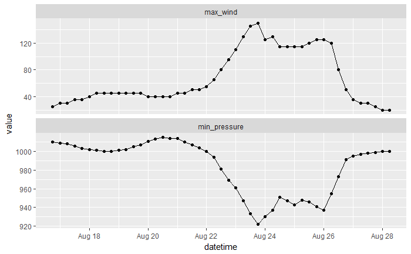

```r
andrew_tracks  %>%
  gather(measure, value, -datetime)  %>%
  ggplot(aes(x = datetime, y = value)) +
  geom_point() + geom_line() +
  facet_wrap(~ measure, ncol = 1, scales = "free_y")
```

# Pulling out date and time elements

Once an object is in a date or date-time class (POSIXIt or POSIXct, respectively), there are other functions in the lubridate package you can use to pull certain elements out of it. For example, you can use the functions year, months, mday, wday, weekdays, hour, minute, and second to pull the year, month, month day, etc., of the date. The following code uses the datetime variable in the Hurricane Andrew track data to add new columns for the year, month, weekday, year day, and hour of each observation:

```r
andrew_tracks  %>%
  select(datetime)  %>%
  mutate(year = year(datetime),
         month = months(datetime),
         weekday = weekdays(datetime),
         yday = yday(datetime),
         hour = hour(datetime))  %>%
  slice(1:3)
```

| datetime | year | month | weekday | yday | hour |
| --- | --- | --- | --- | --- | --- |
| 1992-08-16 18:00:00 | 1992 | August | Sunday | 229 | 18 |
| 1992-08-17 00:00:00 | 1992 | August | Monday | 230 | 0 |
| 1992-08-17 06:00:00 | 1992 | August | Monday | 230 | 6 |

This functionality makes it easy to look at patterns in the max_wind value by different time groupings, like weekday and month. For example, the following code puts together some of the dplyr and tidyr data cleaning tools and ggplot2 plotting functions with these lubridate functions to look at the average value of max_wind storm observations by day of the week and by month.

```r
check_tracks <- ext_tracks  %>%
  select(month, day, hour, year, max_wind)  %>%
  unite(datetime, year, month, day, hour)  %>%
  mutate(datetime = ymd_h(datetime),
         weekday = weekdays(datetime),
         weekday = factor(weekday, levels=c("Sunday", "Monday", "Tuesday","Wednesday",
                                            "Thursday", "Friday","Saturday")),
         month = months(datetime),
         month = factor(month, levels=c("April","May","June","July","August","September",
                                        "October","November","December","January")))
check_weekdays <- check_tracks  %>%
  group_by(weekday)  %>%
  summarize(ave_max_wind = mean(max_wind))  %>%
  rename(grouping = weekday)
check_months <- check_tracks  %>%
  group_by(month)  %>%
  summarize(ave_max_wind = mean(max_wind))  %>%
  rename(grouping = month)
a <- ggplot(check_weekdays, aes(x=grouping, y=ave_max_wind)) +
  geom_bar(stat = "identity") + xlab("")
b <- a %+% check_months
library(gridExtra)
```

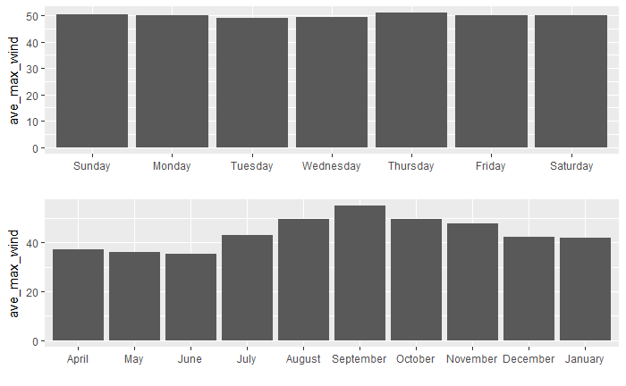

```r
grid.arrange(a, b, ncol=1)
```

Based on the above figure, there’s little pattern in storm intensity by day of the week, but there is a pattern by month, with the highest average wind speed measurements in observations in September and neighboring months (and no storm observations in February and March). There are a few other interesting things to note about this code:

1. To get the weekday and month values in the right order, the code uses the factor function in conjunction with the levels option, to control the order in which R sets the factor levels. By specifying the order we want to use with levels, the plot prints our using this order, rather than alphabetical order (try the code without the factor calls for month and weekday and compare the resulting graphs to the ones shown here).
2. The **grid.arrange** function, from the **gridExtra** package, allows you to arrange different ggplot objects in the same plot area. Here, we’ve used it to put the bar charts for weekday and for month together in one column (ncol=1).
3. If you ever have ggplot code that you would like to re-use for a new plot with a different dataframe, you can save a lot of copying and pasting by using the **%+%** function. This function takes a ggplot object (a in this case, which is the bar chart by weekday) and substitutes a different dataframe (check_months) for the original one (check_weekdays), but otherwise maintains all code. Note that we used rename to give the x-variable the same name in both datasets so we could take advantage of the **%+%** function.

# Working with timezones

```r
andrew_tracks <- ext_tracks  %>%
  filter(storm_name == "ANDREW")  %>%
  slice(23:47)  %>%
  select(year, month, day, hour, latitude, longitude)  %>%
  unite(datetime, year, month, day, hour)  %>%
  mutate(datetime = ymd_h(datetime),
         date = format(datetime, "%b %d"))
# First we need to install ggmap package
if (!require("ggmap")) {
  install.packages("ggmap", dependencies=TRUE)
  library(ggmap)
}
```

```r
miami <- get_map("miami", zoom = 5)
```

[output not shown]

```r
ggmap(miami) +
  geom_path(data = andrew_tracks, aes(x = -longitude, y = latitude),
            color = "gray", size = 1.1) +
  geom_point(data = andrew_tracks, aes(x = -longitude, y = latitude, color = date),
             size = 2)
```

[output not shown]

TO create this plot using local time for Miami, FL, rather than UTC, you can use the with_tz function from lubridate to convert the datetime variable in the track data from UTC to local time. This function inputs a date-time object in the POSIXct class, as well as a character string with the time zone of the location fro which you’d like to get local time, and returns the corrresponding local time for that location.

```r
andrew_tracks <- andrew_tracks   %>%
  mutate(datetime = with_tz(datetime, tzone = "America/New_York"),
         date = format(datetime, "%b %d"))
ggmap(miami) +
  geom_path(data = andrew_tracks, aes(x = -longitude, y = latitude),
            color = "gray", size = 1.1) +
  geom_point(data = andrew_tracks, aes(x = -longitude, y = latitude, color = date),
             size = 2)
```

[output not shown]